# API main approach

Marvin, Isabel

2025-03-18

## Introduction

[Alpha Vantage’s API](https://www.alphavantage.co) offers access to a wide array of financial data, among other things financial metrics for the 500 companies of the S&P 500 that we are interested in. We have developed three approaches to access the data. They all revolve around the central problem of circumventing Alpha Vantage API’s request limits. Alpha Vantage has a hard limit of 25 requests per API key per day. Moreover, Alpha Vantage tracks the user’s IP address and sets the same hard limit. Hence, a simple API key rotation would not work, as this would limit us to only 25 downloads per day. However, we developed a framework to combine a simple API key rotation with regular changes of the IP address, using [Auto Tor](https://github.com/FDX100/Auto_Tor_IP_changer). This is our main approach, which enabled us to get the data for the 500 companies in a fast and efficient way.

## Auto Tor IP Changer View

Below is how the Auto Tor terminal looks like when running:

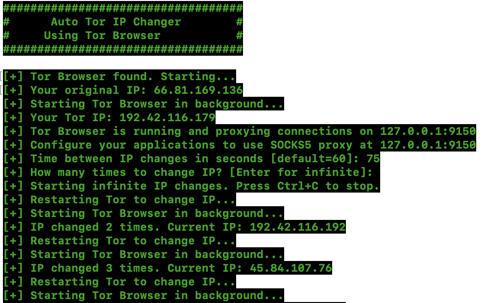

Auto Tor IP Changer Terminal

This tool changes one’s IP address automatically by restarting the Tor Browser at regular specified intervals. For this code, we recommend 75 seconds.

## Packages

```r
library(httr)
library(jsonlite)
library(curl)
library(dotenv)
```

## IP connection function

We start with this function which verifies that we have a proper Tor connection and retrieves the current IP address. It is essential for confirming that we have a working anonymous connection before making API requests.

```r
# function to check current IP
check_current_ip <- function(max_attempts = 3) {
  for (attempt in 1:max_attempts) {
    tryCatch({
      # configure to use Tor SOCKS proxy
      h <- new_handle()
      handle_setopt(h, proxy = "socks5h://127.0.0.1:9150")
      handle_setopt(h, timeout = 30)

      # gt IP through Tor
      cat("Checking IP (attempt", attempt, ")...\n")
      response <- curl_fetch_memory("https://api.ipify.org", h)
      ip_address <- rawToChar(response$content)

      cat("Current IP through Tor:", ip_address, "\n")
      return(ip_address)
    }, error = function(e) {
      cat("Error checking IP (attempt", attempt, "):", e$message, "\n")
      if (attempt < max_attempts) {
        cat("Waiting 5 seconds before retry...\n")
        Sys.sleep(5)
      }
    })
  }
  return(NULL)
}
```

## Data retrieval function

This function connects to Alpha Vantage’s API via Tor and then tries to retrieve financial data for a specific company. The function includes some error handling and logging for API rate limits and connection issues. We add a customizable argument such that the user can choose the number of retry attempts.

```r
# function to get company data via Alpha Vantage
get_company_data <- function(symbol, api_key, max_attempts = 3) {
  for (attempt in 1:max_attempts) {
    # set up the Tor proxy with curl package
    h <- new_handle()
    handle_setopt(h, proxy = "socks5h://127.0.0.1:9150")
    handle_setopt(h, timeout = 30)

    # build the Alpha Vantage API URL
    url <- paste0(
      "https://www.alphavantage.co/query?function=OVERVIEW&symbol=",
      symbol,
      "&apikey=",
      api_key
    )

    cat("Fetching data for", symbol, "(attempt", attempt, ")...\n")

    # make the request through Tor
    tryCatch({
      response <- curl_fetch_memory(url, h)

      # Parse the JSON response
      data <- fromJSON(rawToChar(response$content))

      # Check for API errors or limits
      if (!is.null(data$Information) && grepl("API rate limit", data$Information)) {
        cat("API rate limit hit for", symbol, "\n")
        if (attempt < max_attempts) {
          cat("Waiting for IP rotation before retry...\n")
          Sys.sleep(15)  # Wait for IP rotation
          next
        }
        return(NULL)
      }

      if (!is.null(data$`Error Message`)) {
        cat("API Error for", symbol, ":", data$`Error Message`, "\n")
        return(NULL)
      }

      if (length(data) == 0 || (length(data) == 1 && is.null(names(data)))) {
        cat("Empty response received for", symbol, "\n")
        return(NULL)
      }

      cat("Successfully fetched data for", symbol, "\n")
      return(data)

    }, error = function(e) {
      cat("Error fetching data for", symbol, "(attempt", attempt, "):", e$message, "\n")
      if (attempt < max_attempts) {
        cat("Waiting before retry...\n")
        Sys.sleep(5)
      }
    })
  }
  return(NULL)
}
```

## Data processing function

Here, we transform the JSON responses from Alpha Vantage into nicer, structured dataframes. We only use one API endpoint because each endpoint would require us to do a separate call, costing us one additional request. And the overview endpoint gives us most of the relevant information about a company’s financial health. The extract_company_metrics function parses financial data into meaningful categories. It also handles missing values.

```r
# function to extract comprehensive metrics from the OVERVIEW endpoint
extract_company_metrics <- function(data, symbol) {
  tryCatch({
    metrics <- data.frame(
      # basic Information
      Symbol = symbol,
      Name = ifelse(is.null(data$Name), NA, data$Name),
      Sector = ifelse(is.null(data$Sector), NA, data$Sector),
      Industry = ifelse(is.null(data$Industry), NA, data$Industry),

      # valuation Metrics
      PE_Ratio = ifelse(is.null(data$PERatio), NA, as.numeric(data$PERatio)),
      PEG_Ratio = ifelse(is.null(data$PEGRatio), NA, as.numeric(data$PEGRatio)),
      Price_to_Book = ifelse(is.null(data$PriceToBookRatio), NA, as.numeric(data$PriceToBookRatio)),
      Price_to_Sales = ifelse(is.null(data$PriceToSalesRatioTTM), NA, as.numeric(data$PriceToSalesRatioTTM)),
      EV_to_EBITDA = ifelse(is.null(data$EVToEBITDA), NA, as.numeric(data$EVToEBITDA)),
      EV_to_Revenue = ifelse(is.null(data$EVToRevenue), NA, as.numeric(data$EVToRevenue)),

      # profitability measures
      Profit_Margin = ifelse(is.null(data$ProfitMargin), NA, as.numeric(data$ProfitMargin)),
      Operating_Margin = ifelse(is.null(data$OperatingMarginTTM), NA, as.numeric(data$OperatingMarginTTM)),
      Return_on_Assets = ifelse(is.null(data$ReturnOnAssetsTTM), NA, as.numeric(data$ReturnOnAssetsTTM)),
      Return_on_Equity = ifelse(is.null(data$ReturnOnEquityTTM), NA, as.numeric(data$ReturnOnEquityTTM)),

      # growth indicators
      Revenue_Growth_YOY = ifelse(is.null(data$QuarterlyRevenueGrowthYOY), NA, as.numeric(data$QuarterlyRevenueGrowthYOY)),
      EPS_Growth_YOY = ifelse(is.null(data$QuarterlyEarningsGrowthYOY), NA, as.numeric(data$QuarterlyEarningsGrowthYOY)),

      # financial Health
      Current_Ratio = ifelse(is.null(data$CurrentRatio), NA, as.numeric(data$CurrentRatio)),
      Debt_to_Equity = ifelse(is.null(data$DebtToEquityRatio), NA, as.numeric(data$DebtToEquityRatio)),
      Interest_Coverage = ifelse(is.null(data$InterestCoverageRatio), NA, as.numeric(data$InterestCoverageRatio)),

      # dividend & Shareholder Returns
      Dividend_Yield = ifelse(is.null(data$DividendYield), NA, as.numeric(data$DividendYield)),
      Dividend_Per_Share = ifelse(is.null(data$DividendPerShare), NA, as.numeric(data$DividendPerShare)),
      Dividend_Payout_Ratio = ifelse(is.null(data$PayoutRatio), NA, as.numeric(data$PayoutRatio)),

      # market & technical stuff
      Beta = ifelse(is.null(data$Beta), NA, as.numeric(data$Beta)),
      Fifty_Two_Week_High = ifelse(is.null(data$`52WeekHigh`), NA, as.numeric(data$`52WeekHigh`)),
      Fifty_Two_Week_Low = ifelse(is.null(data$`52WeekLow`), NA, as.numeric(data$`52WeekLow`)),

      # additional size/scale Metrics
      Market_Cap = ifelse(is.null(data$MarketCapitalization), NA, as.numeric(data$MarketCapitalization)),
      EBITDA = ifelse(is.null(data$EBITDA), NA, as.numeric(data$EBITDA)),
      Revenue_TTM = ifelse(is.null(data$RevenueTTM), NA, as.numeric(data$RevenueTTM)),

      stringsAsFactors = FALSE)

    return(metrics)
  }, error = function(e) {
    cat("Error processing data for", symbol, ":", e$message, "\n")
    # return minimal data if error occurs
    data.frame(Symbol = symbol, Name = NA, Sector = NA, stringsAsFactors = FALSE)
  })
}

# some simple scraping: function to get S&P 500 symbols
get_sp500_symbols <- function() {
  tryCatch({
    # Using Wikipedia as source
    url <- "https://en.wikipedia.org/wiki/List_of_S%26P_500_companies"

    # Import libraries if needed
    if (!requireNamespace("rvest", quietly = TRUE)) {
      install.packages("rvest")
      library(rvest)
    } else {
      library(rvest)
    }

    # scrape the table
    page <- read_html(url)
    tables <- html_nodes(page, "table.wikitable")
    sp500_table <- html_table(tables[1], fill = TRUE)[[1]]

    # extract symbols
    symbols <- sp500_table$Symbol

    # clean symbols (remove .* if present)
    symbols <- gsub("\\.", "-", symbols)

    cat("Retrieved", length(symbols), "S&P 500 symbols\n")
    return(symbols)
  }, error = function(e) {
    cat("Error retrieving S&P 500 symbols:", e$message, "\n")
    cat("Using backup S&P 500 symbols list\n")

    # backup list of major S&P 500 components (top 30 by weight)
    backup_symbols <- c("AAPL", "MSFT", "AMZN", "NVDA", "GOOGL", "META", "GOOG", "BRK-B",
                        "UNH", "LLY", "JPM", "XOM", "V", "AVGO", "PG", "MA", "HD", "COST",
                        "MRK", "ABBV", "CVX", "PEP", "KO", "ADBE", "WMT", "CRM", "BAC",
                        "TMO", "ACN", "MCD")
    return(backup_symbols)
  })
}
```

## Main data collection function

This is our core function that organises the entire data collection process.

It coordinates everything: checking Tor connections, rotating through API keys to avoid hitting limits, fetching company data, and saving our progress. When something goes wrong (like a failed request), it adds the company to a retry queue and uses a cool exponential backoff - waiting longer between each retry attempt. We also added a functionality that saves the progress after each successful company to batch_progress_temp.csv, so we don’t lose data if anything goes wrong.

```r
# modified collection function that uses CSV instead of RDS for progress tracking
collect_data_tor <- function(symbols, api_keys, interval_seconds = 75,
                             stabilization_seconds = 25, max_retries = 3,
                             requests_per_key = 25) {
  cat("Starting data collection using Tor rotation and API key rotation\n")
  cat("Using", length(api_keys), "API keys with", requests_per_key, "requests per key\n")

  # check if Tor is running
  cat("Verifying Tor connection...\n")
  initial_ip <- check_current_ip()
  if (is.null(initial_ip)) {
    cat("ERROR: Cannot connect to Tor. Make sure the Tor Browser is running.\n")
    return(NULL)
  }

  cat("Tor connection verified. Initial IP:", initial_ip, "\n")

  # initialize results dataframe and retry queue
  results_df <- data.frame()
  retry_queue <- data.frame(
    symbol = character(0),
    attempts = integer(0),
    last_error = character(0),
    stringsAsFactors = FALSE
  )

  # API key tracking
  current_key_index <- 1
  current_key <- api_keys[current_key_index]
  requests_with_current_key <- 0

  # process each symbol
  for (i in seq_along(symbols)) {
    symbol <- symbols[i]
    cat("\n==== Processing", i, "of", length(symbols), ":", symbol, "====\n")

    # API key rotation check
    if (requests_with_current_key >= requests_per_key) {
      current_key_index <- current_key_index %% length(api_keys) + 1
      current_key <- api_keys[current_key_index]
      cat("\n*** Rotating to API key", current_key_index, "of", length(api_keys), "***\n")
      requests_with_current_key <- 0
    }

    # add stabilization period before each request to ensure Tor connection is ready
    if (i > 1) {  # skip first symbol as we already verified connection
      cat("Waiting", stabilization_seconds, "seconds for Tor connection to stabilize...\n")
      Sys.sleep(stabilization_seconds)
    }

    # check current IP with multiple retries
    current_ip <- NULL
    for (retry in 1:5) {  # Up to 5 retries for IP check
      current_ip <- check_current_ip(max_attempts = 1)  # Single attempt per retry
      if (!is.null(current_ip)) break
      cat("Retrying IP check in 3 seconds...\n")
      Sys.sleep(3)
    }

    if (is.null(current_ip)) {
      cat("WARNING: Could not verify Tor IP before processing", symbol, "\n")
      cat("Adding", symbol, "to retry queue for safety\n")
      retry_queue <- rbind(retry_queue, data.frame(
        symbol = symbol,
        attempts = 0,
        last_error = "Could not verify Tor IP",
        stringsAsFactors = FALSE
      ))
      # wait the standard interval before continuing
      if (i < length(symbols)) {
        cat("Waiting", interval_seconds, "seconds before next symbol...\n")
        Sys.sleep(interval_seconds)
      }
      next  # skip this symbol for now
    }

    cat("Using IP:", current_ip, "\n")

    # get data
    cat("Using API key:", substr(current_key, 1, 5), "...\n")
    data <- get_company_data(symbol, current_key)
    requests_with_current_key <- requests_with_current_key + 1

    if (!is.null(data)) {
      # extract metrics and add to results dataframe
      symbol_metrics <- extract_company_metrics(data, symbol)

      # check if the results_df is empty
      if (nrow(results_df) == 0) {
        results_df <- symbol_metrics
      } else {
        results_df <- rbind(results_df, symbol_metrics)
      }

      cat("Data for", symbol, "collected successfully\n")
      cat("API key", current_key_index, "has been used for", requests_with_current_key, "requests\n")

      # save progress to a temporary batch file after each successful request
      batch_temp_file <- paste0("batch_progress_temp.csv")
      write.csv(results_df, batch_temp_file, row.names = FALSE)
      cat("Progress saved to temporary file\n")
    } else {
      cat("Failed to get data for", symbol, ", adding to retry queue\n")
      retry_queue <- rbind(retry_queue, data.frame(
        symbol = symbol,
        attempts = 0,
        last_error = "Initial fetch failed",
        stringsAsFactors = FALSE
      ))
    }

    # wait for the next IP rotation from the aut script
    if (i < length(symbols)) {
      cat("Waiting", interval_seconds, "seconds for next IP rotation...\n")
      Sys.sleep(interval_seconds)
    }
  }

  # process retry queue with exponential backoff
  if (nrow(retry_queue) > 0) {
    cat("\n\n==== Processing retry queue ====\n")
    cat("There are", nrow(retry_queue), "symbols in the retry queue\n")

    # wait longer before starting retries to ensure Tor is stable
    retry_wait <- 180  # 3 minutes initial wait
    cat("Waiting", retry_wait, "seconds before starting retries...\n")
    Sys.sleep(retry_wait)

    # continue retrying until queue is empty or max retries reached
    while (nrow(retry_queue) > 0) {
      # get first symbol from queue
      current <- retry_queue[1, ]
      symbol <- current$symbol
      attempts <- current$attempts + 1

      # check if we've reached max retries
      if (attempts > max_retries) {
        cat("\nSymbol", symbol, "has reached maximum retry attempts (", max_retries, ")\n")
        cat("Giving up on this symbol\n")
        # Remove from queue
        retry_queue <- retry_queue[-1, ]
        next
      }

      # API key rotation for retries too
      if (requests_with_current_key >= requests_per_key) {
        current_key_index <- current_key_index %% length(api_keys) + 1
        current_key <- api_keys[current_key_index]
        cat("\n*** Rotating to API key", current_key_index, "of", length(api_keys), "for retry ***\n")
        requests_with_current_key <- 0
      }

      # calculate exponential backoff
      backoff_time <- 30 * (2 ^ (attempts - 1))  # 30, 60, 120 seconds...

      cat("\n==== Retry attempt", attempts, "for", symbol, "====\n")
      cat("Previous error:", current$last_error, "\n")

      # verify Tor connection
      cat("Verifying Tor connection for retry...\n")
      current_ip <- check_current_ip()

      if (is.null(current_ip)) {
        cat("WARNING: Could not verify Tor IP for retry. Waiting", backoff_time, "seconds...\n")
        Sys.sleep(backoff_time)

        # update retry queue
        retry_queue$attempts[1] <- attempts
        retry_queue$last_error[1] <- "Could not verify Tor IP on retry"
        # move to the end of the queue
        retry_queue <- rbind(retry_queue[-1, ], retry_queue[1, ])
        next
      }

      cat("Using IP for retry:", current_ip, "\n")

      # get data
      cat("Using API key:", substr(current_key, 1, 5), "...\n")
      data <- get_company_data(symbol, current_key)
      requests_with_current_key <- requests_with_current_key + 1

      if (!is.null(data)) {
        # extract metrics and add to results dataframe
        symbol_metrics <- extract_company_metrics(data, symbol)

        # add to results dataframe
        if (nrow(results_df) == 0) {
          results_df <- symbol_metrics
        } else {
          results_df <- rbind(results_df, symbol_metrics)
        }

        cat("Data for", symbol, "collected successfully on retry\n")
        cat("API key", current_key_index, "has been used for", requests_with_current_key, "requests\n")

        # save progress to a temporary batch file
        batch_temp_file <- paste0("batch_progress_temp.csv")
        write.csv(results_df, batch_temp_file, row.names = FALSE)
        cat("Progress saved to temporary file\n")

        # remove from retry queue
        retry_queue <- retry_queue[-1, ]
      } else {
        cat("Retry failed for", symbol, ". Waiting", backoff_time, "seconds...\n")
        Sys.sleep(backoff_time)

        # update retry queue
        retry_queue$attempts[1] <- attempts
        retry_queue$last_error[1] <- paste("Retry", attempts, "failed")
        # move to the end of the queue
        retry_queue <- rbind(retry_queue[-1, ], retry_queue[1, ])
      }
    }
  }

  cat("\n==== Data collection complete ====\n")
  cat("Successfully collected data for", nrow(results_df), "out of", length(symbols), "symbols\n")

  # return results
  return(results_df)
}
```

## API key management

This section loads our manually collected API keys from the environment to access the Alpha Vantage API.

```r
# load environment variables
dotenv::load_dot_env()

# get API keys from environment
get_api_keys <- function() {
  # get all environment variables
  all_env <- Sys.getenv()

  # filter for Alpha Vantage keys
  key_names <- grep("^ALPHA_VANTAGE_KEY_", names(all_env), value = TRUE)

  # extract the values
  api_keys <- sapply(key_names, function(key) Sys.getenv(key))

  # filter out empty keys
  api_keys <- api_keys[api_keys != ""]

  if (length(api_keys) == 0) {
    stop("No Alpha Vantage API keys found in environment variables. Please check your .env file.")
  }

  cat("Found", length(api_keys), "API keys in environment variables\n")
  return(api_keys)
}

# get API keys from environment
api_keys <- get_api_keys()
```

```
## Found 27 API keys in environment variables
```

## Execute the data collection

Finally, we execute the data collection process and track progress. This chunk manages previously collected data, randomly selects new companies to process, and updates the combined dataset called sp500_fundamentals_combined.csv.

```r
# load existing progress from CSV
if (file.exists("sp500_fundamentals_combined.csv")) {
  combined_df <- read.csv("sp500_fundamentals_combined.csv", stringsAsFactors = FALSE)
  already_collected <- combined_df$Symbol
  cat("Already collected data for", length(already_collected), "companies from CSV file:\n")
  cat(paste(already_collected, collapse=", "), "\n\n")
} else {
  combined_df <- data.frame()
  already_collected <- c()
}
```

```
## Already collected data for 499 companies from CSV file:
## AAPL, MSFT, GOOGL, AMZN, META, MMM, AOS, ABT, ABBV, ACN, ADBE, AMD, AES, AFL, A, APD, ABNB, AKAM, ALB, ARE, ALGN, ALLE, LNT, ALL, GOOG, MO, AEE, AEP, AXP, AIG, AMT, AWK, AMP, AME, AMGN, APH, ADI, ANSS, AON, APA, APO, AMAT, APTV, ACGL, ADM, ANET, AJG, AIZ, T, ATO, ADSK, ADP, AZO, AVB, AVY, AXON, B…
```

```r
# get full S&P 500 list
all_sp500 <- get_sp500_symbols()
```

```
## Retrieved 503 S&P 500 symbols
```

```r
# Remove companies already collected
remaining_symbols <- all_sp500[!all_sp500 %in% already_collected]
cat("Remaining companies to collect:", length(remaining_symbols), "\n")
```

```
## Remaining companies to collect: 4
```

```r
# HERE: define how many companies to collect in this run
companies_to_collect <- 2  # adjust this number as needed for testing

# randomly sample from remaining symbols
if (length(remaining_symbols) > 0) {
  # ff we have fewer remaining symbols than requested, collect all of them
  if (length(remaining_symbols) <= companies_to_collect) {
    batch_symbols <- remaining_symbols
    cat("Collecting all remaining", length(batch_symbols), "symbols:\n")
  } else {
    # randomly sample the requested number
    set.seed(Sys.time()) # Use current time as seed for true randomness
    batch_symbols <- sample(remaining_symbols, companies_to_collect)
    cat("Collecting", companies_to_collect, "randomly selected symbols:\n")
  }

  cat(paste(batch_symbols, collapse=", "), "\n\n")

  # collect data for this batch
  batch_results <- collect_data_tor(
    symbols = batch_symbols,
    api_keys = api_keys,
    interval_seconds = 75,
    stabilization_seconds = 25,
    max_retries = 3,
    requests_per_key = 25)

  # process and save the results for this batch
  if (!is.null(batch_results) && nrow(batch_results) > 0) {
    # generate a timestamp for the batch file
    timestamp <- format(Sys.time(), "%Y%m%d_%H%M%S")
    batch_csv_name <- paste0("sp500_fundamentals_batch_", timestamp, ".csv")

    # save this batch as its own CSV
    write.csv(batch_results, batch_csv_name, row.names = FALSE)
    cat("Batch results saved to", batch_csv_name, "\n")

    # if we have previous results, combine them
    if (nrow(combined_df) > 0) {
      # remove any duplicates (in case of overlaps)
      combined_df <- combined_df[!combined_df$Symbol %in% batch_results$Symbol, ]

      # combine with new batch
      full_df <- rbind(combined_df, batch_results)

      # save combined results
      write.csv(full_df, "sp500_fundamentals_combined.csv", row.names = FALSE)
      cat("Combined results updated with", nrow(batch_results), "new companies\n")
      cat("Total companies in combined file:", nrow(full_df), "\n")
    } else {
      # first batch, just save as combined
      write.csv(batch_results, "sp500_fundamentals_combined.csv", row.names = FALSE)
      cat("Combined results file created with", nrow(batch_results), "companies\n")
    }
  } else {
    cat("No data was collected in this run.\n")
  }
} else {
  cat("No more symbols to process. All S&P 500 companies have been collected.\n")
}
```

```
## DD, REGN
##
## Starting data collection using Tor rotation and API key rotation
## Using 27 API keys with 25 requests per key
## Verifying Tor connection...
## Checking IP (attempt 1 )...
## Current IP through Tor: 46.232.251.191
## Tor connection verified. Initial IP: 46.232.251.191
##
## ==== Processing 1 of 2 : DD ====
## Checking IP (attempt 1 )...
## Current IP through Tor: 46.232.251.191
## Using IP: 46.232.251.191
## Using API key: KBJUJ ...
## Fetching data for DD (attempt 1 )...
## Successfully fetched data for DD
## Data for DD collected successfully
## API key 1 has been used for 1 requests
## Progress saved to temporary file
## Waiting 75 seconds for next IP rotation...
##
## ==== Processing 2 of 2 : REGN ====
## Waiting 25 seconds for Tor connection to stabilize...
## Checking IP (attempt 1 )...
## Current IP through Tor: 192.42.116.215
## Using IP: 192.42.116.215
## Using API key: KBJUJ ...
## Fetching data for REGN (attempt 1 )...
## Successfully fetched data for REGN
## Data for REGN collected successfully
## API key 1 has been used for 2 requests
## Progress saved to temporary file
##
## ==== Data collection complete ====
## Successfully collected data for 2 out of 2 symbols
## Batch results saved to sp500_fundamentals_batch_20250318_214130.csv
## Combined results updated with 2 new companies
## Total companies in combined file: 501
```